# EdgeR

## 5. Setting up the Model

Теперь мы готовы настроить модель! Сначала нам нужно указать нашу матрицу проекта, которая описывает настройку эксперимент.

```r
sampleType<- rep("N", ncol(dgList)) #N=normal; T=tumour
sampleType[grep("T", colnames(dgList))] <- "T"
#'grep' is a string matching function.
sampleReplicate <- paste("S", rep(1:3, each=2), sep="")

designMat <- model.matrix(~sampleReplicate + sampleType)
designMat
```

```
  (Intercept) sampleReplicateS2 sampleReplicateS3 sampleTypeT
1           1                 0                 0           0
2           1                 0                 0           1
3           1                 1                 0           0
4           1                 1                 0           1
5           1                 0                 1           0
6           1                 0                 1           1
attr(,"assign")
[1] 0 1 1 2
attr(,"contrasts")
attr(,"contrasts")$sampleReplicate
[1] "contr.treatment"

attr(,"contrasts")$sampleType
[1] "contr.treatment"
```

## 6. Estimating Dispersion

Нам нужно оценить параметр дисперсии для нашей отрицательной биномиальной модели. Так как их всего несколько образцы, трудно точно оценить дисперсию для каждого гена, поэтому нам нужен способ «обмена» информацией между генами.

В edgeR мы используем эмпирический метод Байеса, чтобы «сжать» оценки генетической дисперсии до общей дисперсии. (tagwise dispersion)

```r
dgList <- estimateGLMCommonDisp(dgList, design=designMat)
dgList <- estimateGLMTrendedDisp(dgList, design=designMat)
dgList <- estimateGLMTagwiseDisp(dgList, design=designMat)
```

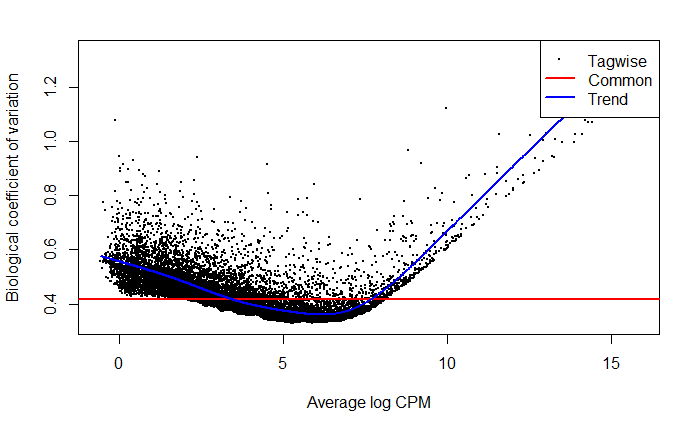

```r
plotBCV(dgList)
```

*The biological coefficient of variation (BCV) is the square root of the dispersion parameter in the negative binomial model.*

## 7.Differential Expression

```r
fit <- glmFit(dgList, designMat)
lrt <- glmLRT(fit, coef=4)
```

Теперь мы можем найти наши дифференциально выраженные гены. После подгонки модели мы можем использовать функцию topTags() для изучения результатов и установить пороги для идентификации подмножеств дифференциально экспрессируемых генов.

```r
edgeR_result <- topTags(lrt)
?topTags
```

Наконец, мы можем построить график логарифмических изменений всех генов и выделить те, которые экспрессируются по-разному.

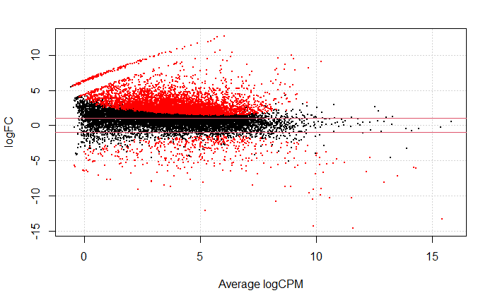

```r
?decideTests
deGenes <- decideTestsDGE(lrt, p=0.001)
deGenes <- rownames(lrt)[as.logical(deGenes)]
plotSmear(lrt, de.tags=deGenes)
abline(h=c(-1, 1), col=2)
```